# Plotting

A. Jesús Muñoz-Pajares, A. Kaliontzopoulou, P. Tarroso

4-8 NOVEMBER 2019

### **General view**

To generate a basic point plot you can use the plot() function.

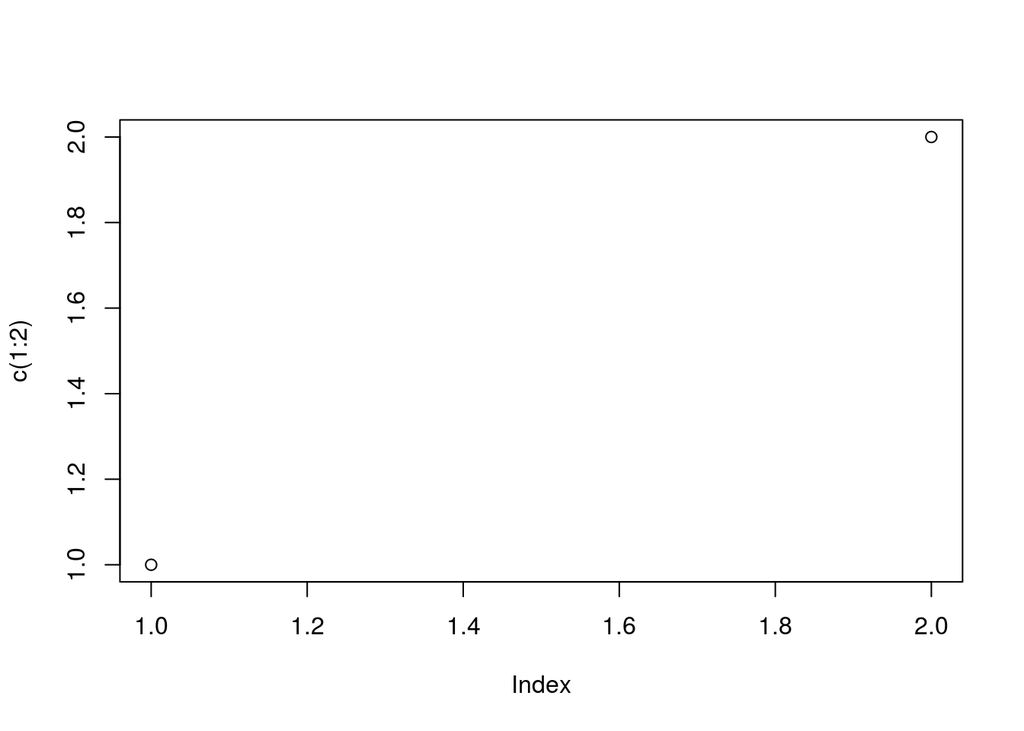

```r
plot(c(1:2))
```

This function perform a plot with two dimensions (Y vs. X). By default, the first vector provided will be considered X and the second Y. If only one vector is provided, Y will be the values of the vector and X their indices. Check this examples:

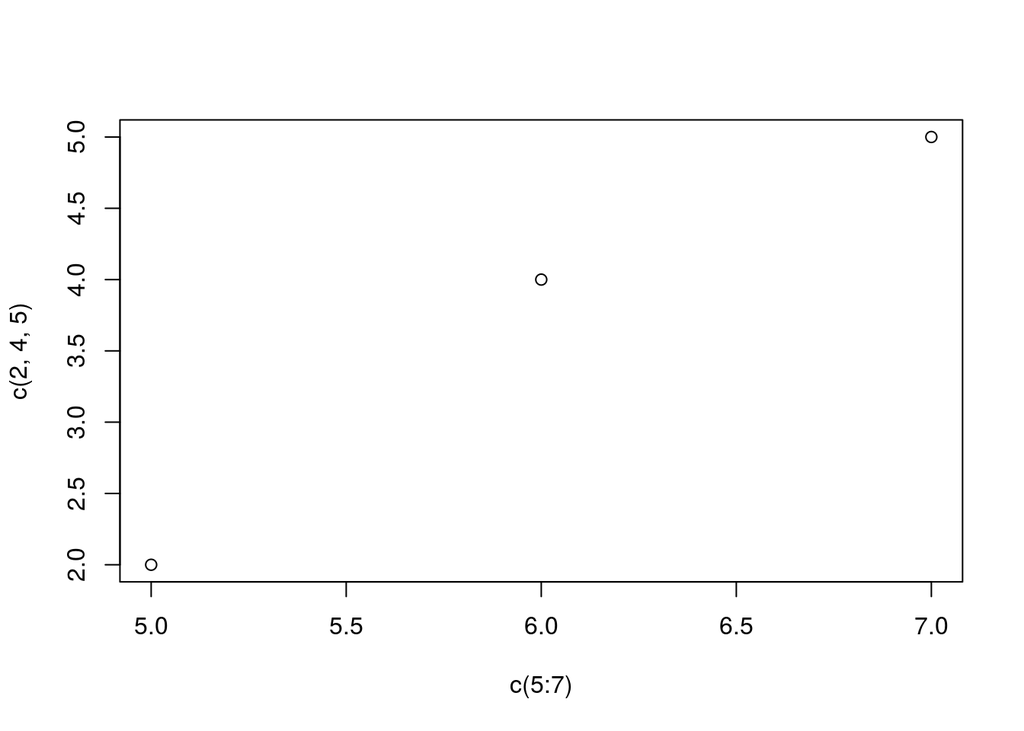

```r
# Plot with x and y ...
plot(c(5:7),c(2,4,5))
# ...   This is the same than:
plot(x=c(5:7),y=c(2,4,5))
```

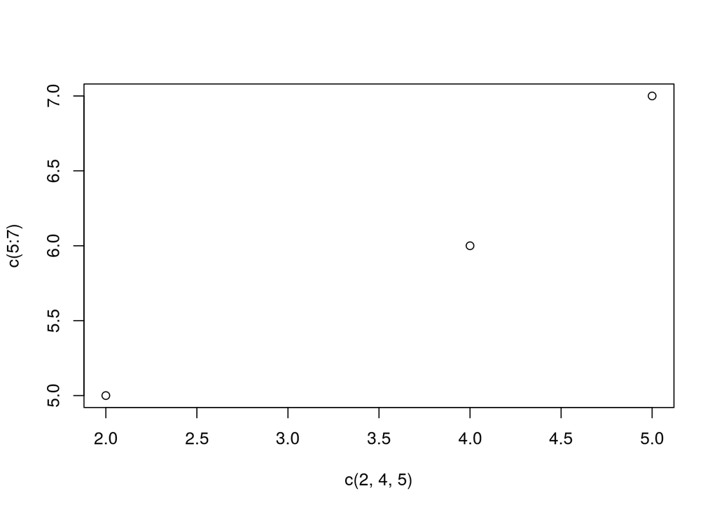

```r
# ...   But this is not:
plot(y=c(5:7),x=c(2,4,5))
```

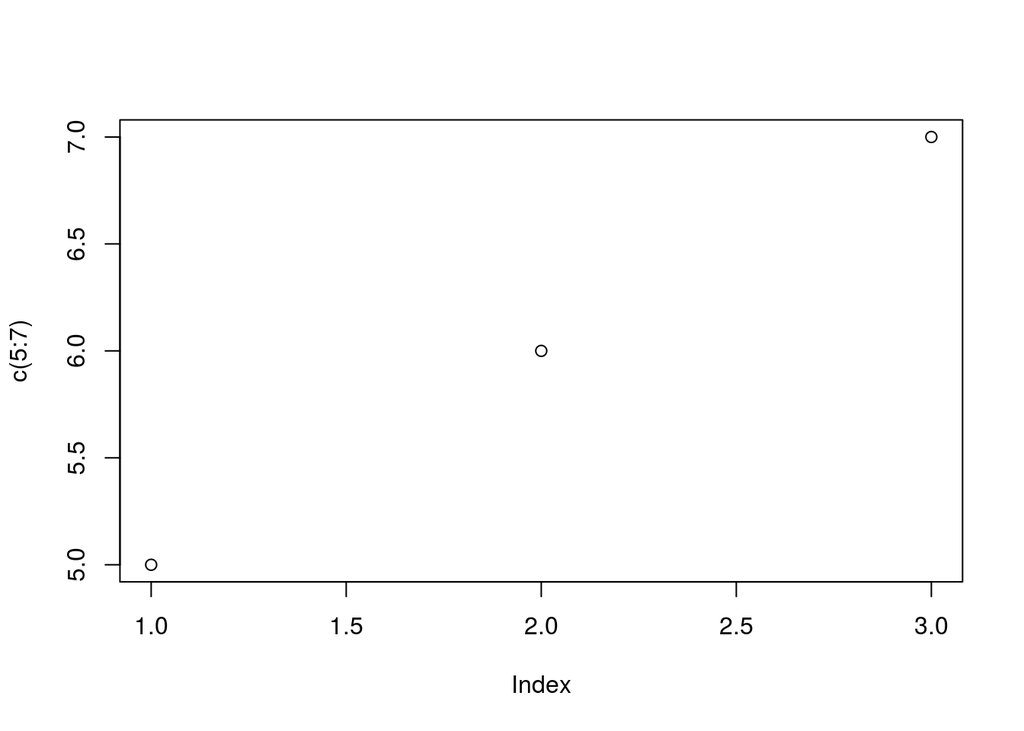

```r
# Plot with only one vector:
plot(c(5:7))
```

If we make another plot, the previous one is removed

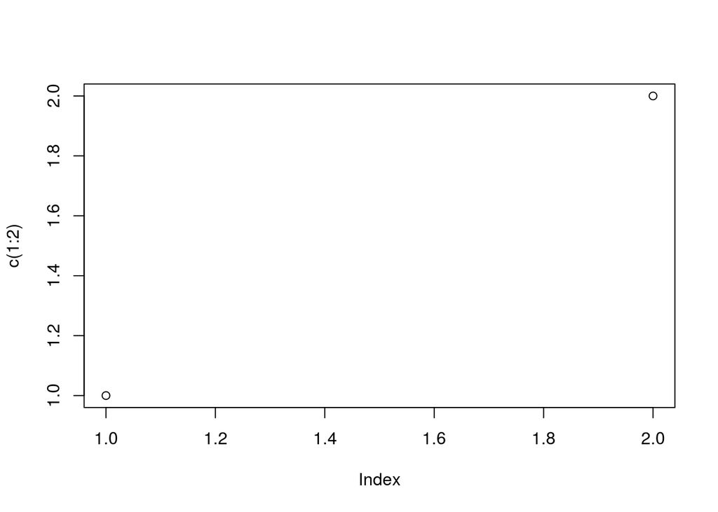

```r
plot(c(1:2))
```

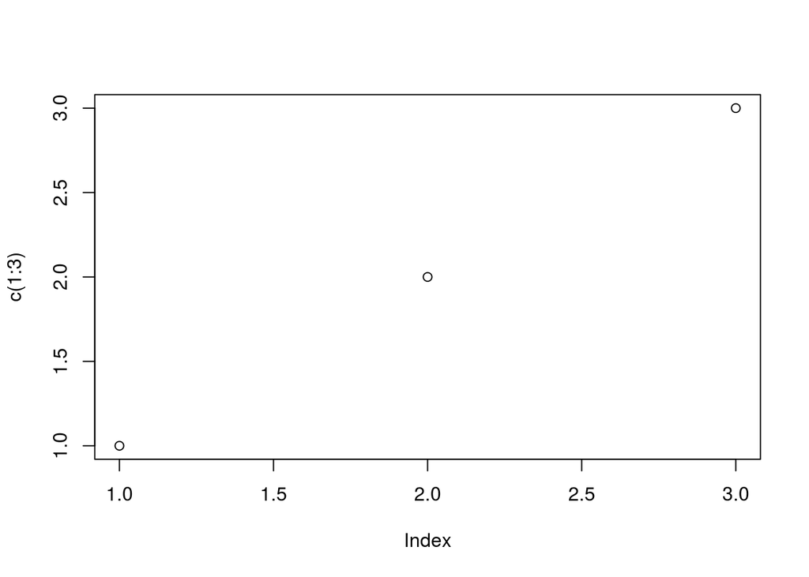

```r
plot(c(1:3))
```

But you can open additional devices using the following functions, some of them system-dependent:

```r
windows()   #Windows
X11()       #Unix
quartz()    #Mac
dev.new()   #All platforms
```

These functions accept arguments to customize the device. For example, width and heigth

```r
dev.new(width=1,height=1)
dev.new(width=5,height=3)
```

Using these functions, we can do a second plot maintaining the former

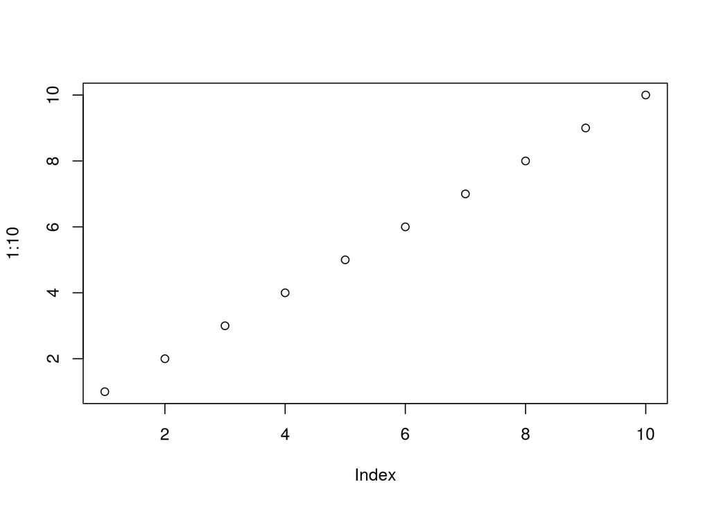

```r
plot(1:10)
```

```r
dev.new()
```

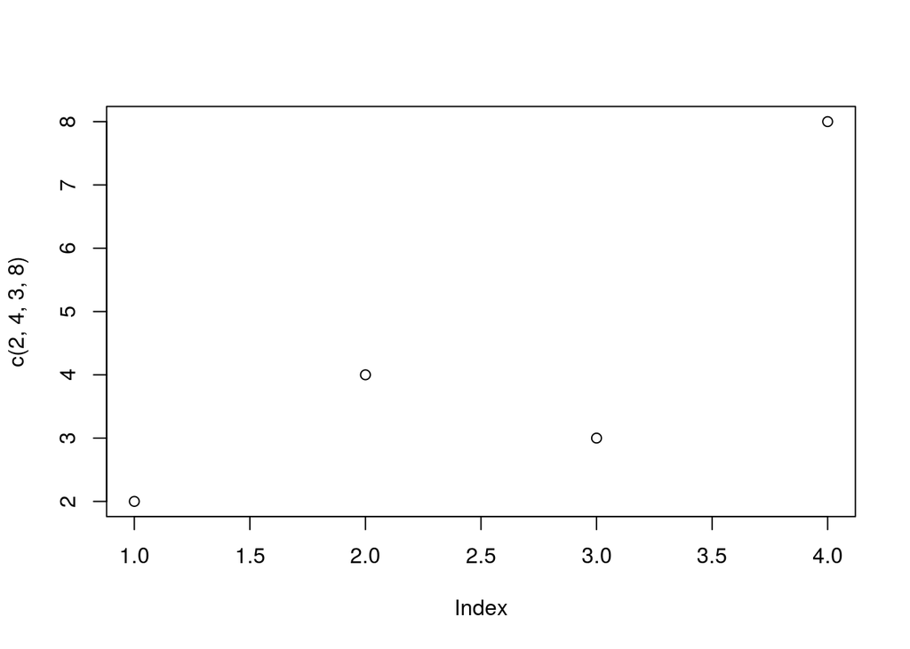

```r
plot(c(2,4,3,8))
```

If you want to mantain the second plot and add some points on it, use points()

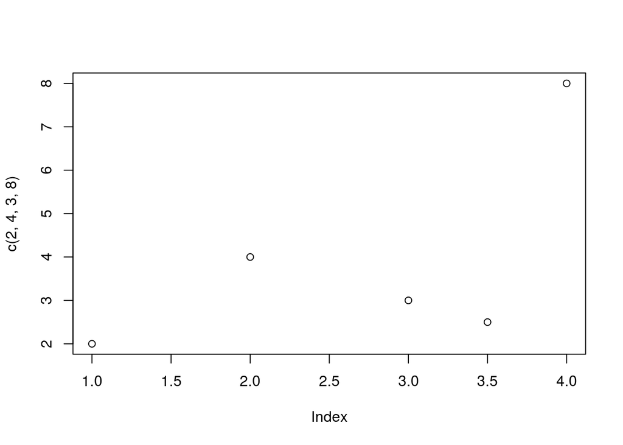

```r
points(x=3.5,y=2.5)
```

If you have several devs, the points will be added to the “ACTIVE” one. You can select dev using dev.set (Note the change in ACTIVE-INACTIVE status):

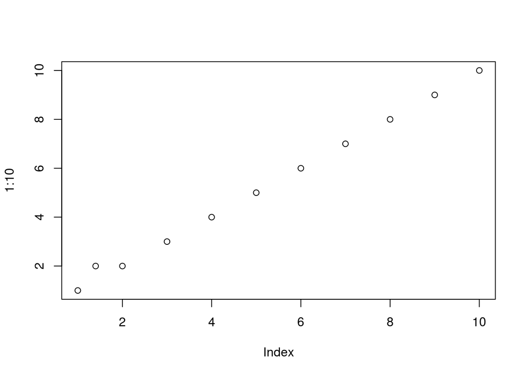

```r
dev.set(1)
points(1.4,2)
```

You can close a device by clicking “X” or using the command:

```r
 dev.off()
```

### **Areas in a plot:**

Every plot has different areas (the plot itself, the margins, the axes, the axis labels, the box, the title,…). You can plot and customize every of this areas using the proper function (text(), mtext(), axis(), box(), main(),…):

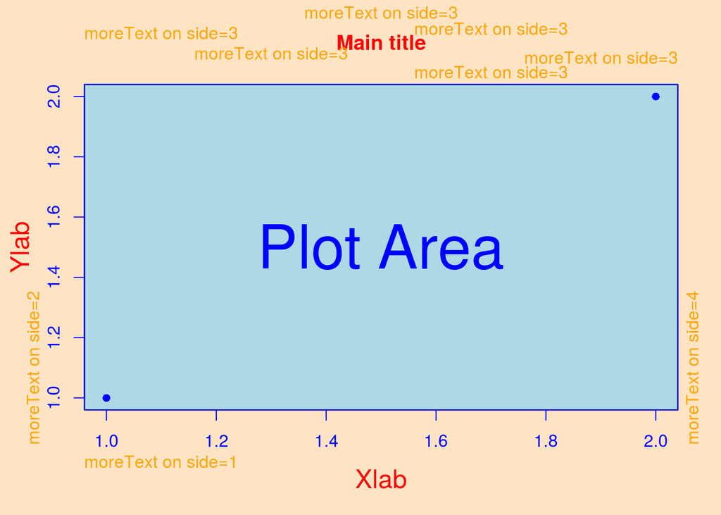

### **Dividing devices to show more than one plot at the same time**

Use layout() to divide the device and layout.show() to see the resulting layout.

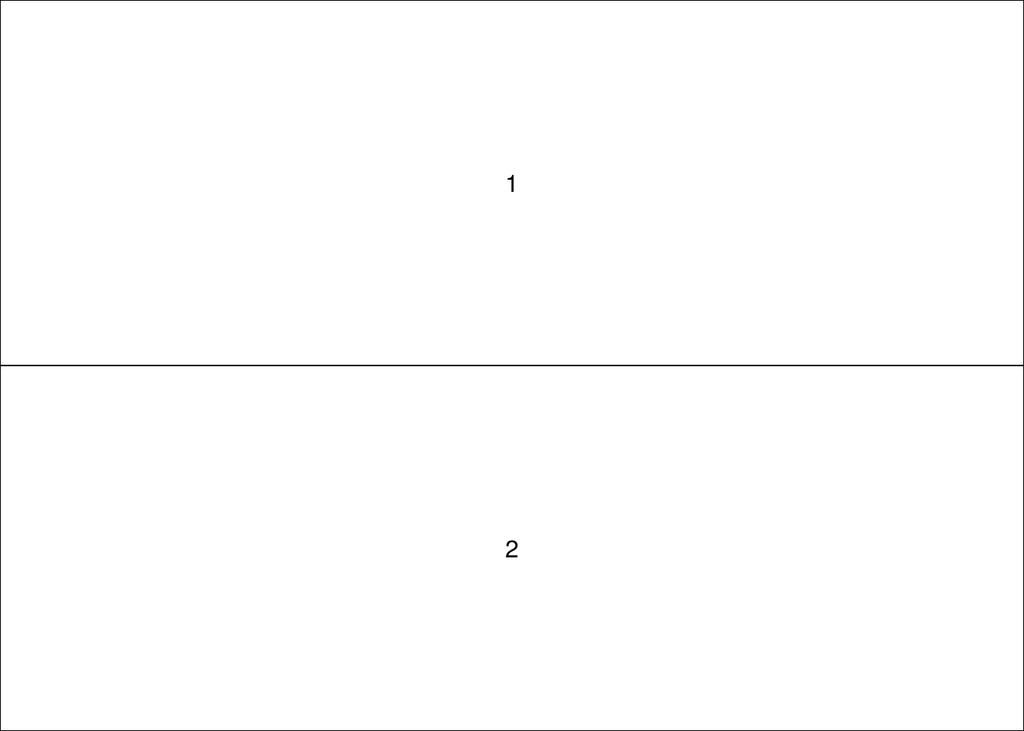

```r
layout(1:2)
layout.show(2)
```

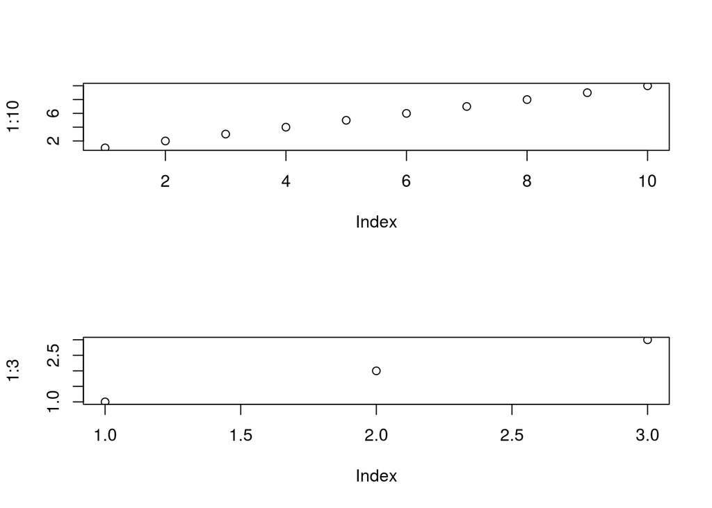

```r
plot(1:10)
plot(1:3)
```

If you want right-left instead of top-bottom or a more complex layout, use set a matrix accordingly.

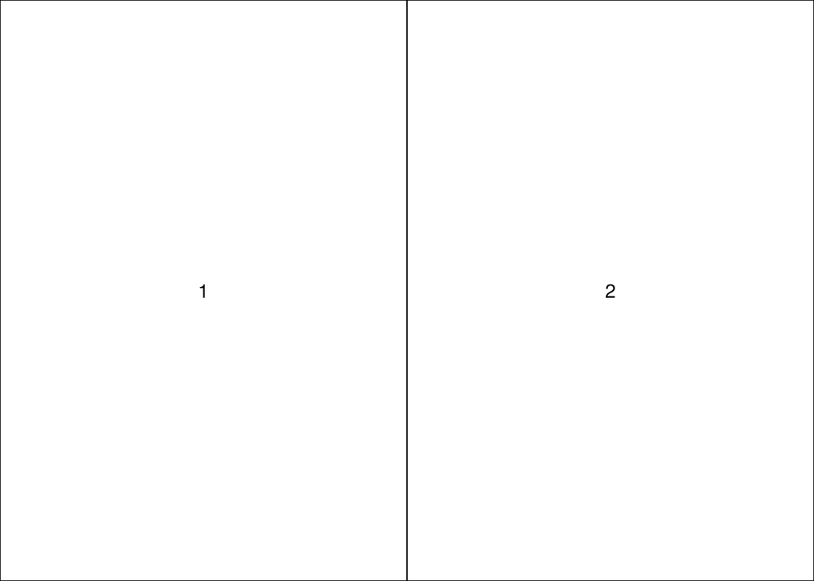

```r
layout(matrix(1:2,ncol=2))
layout.show(2)
```